# stage III prediction on CODEX data

The goal of this notebook is to find which molecules are good predictors of stage III among the cytokine panels collected on the CSF and plasma samples.

```python
import numpy as np
import matplotlib.pyplot as plt
import seaborn as sns
import pandas as pd
```

```python
palette5 = {'III' :'#073B4C',
    'II' : '#118AB2',
       'I' : '#06D6A0',
    'healthy control' : '#FFCE5C',
    'inflammatory control' : '#F26989' }

# purple / green
palette4 = {'ICU COVID' :'#7b3294',
    'Non-ICU COVID' : '#c2a5cf',
    'healthy control' : '#a6dba0',
    'inflammatory control' : '#008837' }
```

# ToC

1. reading the data

2. using ROC - AUC to get the drivers behind the response

- 2.1 I vs. III
- 2.2 II vs. III
- 2.3 I and II vs. III

3. random forest

4. Random forest, Plasma only

## 1. reading the data

```python
## first, grabbing molecule names from the original files (this is a bit dirty...)

df =pd.read_csv('data/Inflammation_Plasma_Etter.csv',sep=';', skiprows=[0,1,2,4,5,6] , index_col=0)
df.drop(columns=['Plate ID' , 'QC Warning'] , inplace=True)

inflammatoryMolecules = list( df.columns )

df =pd.read_csv('data/Neurology_Plasma_Etter.csv',sep=';', skiprows=[0,1,2,4,5,6] , index_col=0)
df.drop(columns=['Plate ID' , 'QC Warning'] , inplace=True)

neuroMolecules = list( df.columns )

## removing common molecules. we keep the ones in neuro
inter = set( inflammatoryMolecules ).intersection(neuroMolecules)
for c in inter:
    inflammatoryMolecules.remove(c)
```

```python
print(len(inflammatoryMolecules))
print(len(neuroMolecules))
```

```
90
92
```

**We use the marginalized molecular data**

```python
## now reading the marginalized molecular data
df_molecular = pd.read_csv( "marginalized_data/data_marginalized_neuroCOVID.csv" , index_col=0 )
df_molecular.drop(columns="stageGroup" , inplace=True)
df_molecular.head()
```

|  | CSF_NMNAT1 | CSF_NRP2 | CSF_MAPT | CSF_CADM3 | CSF_GDNF | CSF_UNC5C | CSF_VWC2 | CSF_Siglec_9 | CSF_CLM_6 | CSF_EZR | ... | Plasma_TNFRSF9 | Plasma_NT_3 | Plasma_TWEAK | Plasma_CCL20 | Plasma_ST1A1 | Plasma_STAMBP | Plasma_IL5 | Plasma_ADA | Plasma_TNFB | Plasma_CSF_1 |
| --- | --- | --- | --- | --- | --- | --- | --- | --- | --- | --- | --- | --- | --- | --- | --- | --- | --- | --- | --- | --- | --- |
| 4927 | 0.783146 | 7.484550 | 4.359968 | 8.166541 | 0.108638 | 4.733553 | 6.869538 | 4.009678 | 4.725901 | 3.476555 | ... | 5.795753 | 1.409262 | 7.279297 | 5.418392 | 0.236511 | 3.412914 | -0.174867 | 3.895639 | 3.732914 | 9.023864 |
| 5050 | 0.455615 | 7.286502 | 4.645233 | 8.172515 | 0.067673 | 5.256008 | 7.272363 | 4.442834 | 4.684212 | 2.823498 | ... | 5.633397 | 2.027130 | 7.871435 | 5.936471 | 0.262972 | 3.278133 | 0.099333 | 4.329668 | 3.477081 | 8.744154 |
| 5052 | 0.594596 | 6.635136 | 3.490066 | 8.149356 | 0.213948 | 4.224093 | 6.016119 | 3.294286 | 4.056793 | 2.549147 | ... | 6.212265 | 1.921543 | 8.165437 | 5.642695 | 0.347999 | 3.302632 | -0.193420 | 4.360193 | 4.213483 | 9.061708 |
| 5062 | 0.590112 | 6.957021 | 3.770465 | 8.076262 | 0.209230 | 4.521448 | 6.355951 | 4.349481 | 3.955589 | 3.046600 | ... | 5.892231 | 1.807028 | 7.978211 | 7.307649 | 0.345256 | 3.686129 | -0.183977 | 4.093367 | 3.674123 | 8.769930 |
| 5092 | 0.742797 | 6.781485 | 2.867935 | 8.159029 | 0.066171 | 3.937601 | 5.994287 | 3.071284 | 3.886460 | 2.290494 | ... | 5.617805 | 0.251490 | 7.912914 | 6.293002 | 2.075751 | 3.948645 | -0.089874 | 3.962206 | 3.573228 | 8.686050 |

5 rows × 364 columns

```python
## and metadata
df_metadata = pd.read_csv('data/metadata.csv', index_col='studyID')
df_metadata.covid = df_metadata.covid.astype(bool)
df_metadata.Age = df_metadata.Age.astype(int)
df_metadata.head()
```

| studyID | Age | Sex | Group | Stage | covid |
| --- | --- | --- | --- | --- | --- |
| 4927 | 38 | f | healthy control | I | False |
| 5050 | 53 | m | healthy control | I | False |
| 5052 | 22 | m | healthy control | I | False |
| 5062 | 23 | m | healthy control | I | False |
| 5092 | 47 | f | healthy control | I | False |

```python
df_metadata["stageGroup"] = df_metadata.Group
df_metadata.loc[df_metadata.covid==True , "stageGroup"] = df_metadata.Stage[df_metadata.covid == True]

pd.crosstab( df_metadata.Group , df_metadata.stageGroup )
```

| stageGroup Group | I | II | III | healthy control | inflammatory control |
| --- | --- | --- | --- | --- | --- |
| ICU COVID | 0 | 0 | 11 | 0 | 0 |
| Non-ICU COVID | 18 | 7 | 4 | 0 | 0 |
| healthy control | 0 | 0 | 0 | 25 | 0 |
| inflammatory control | 0 | 0 | 0 | 0 | 25 |

back to toc

## 2. using ROC - AUC to get the drivers behind the response

### 2.1 I vs. III

```python
from sklearn.metrics import roc_auc_score
from sklearn.metrics import roc_curve, auc


M = df_metadata.index[ ( df_metadata.stageGroup == "I") | (df_metadata.stageGroup == "III") ]

data = df_molecular.loc[ M , : ]
grouping = df_metadata.loc[ M , 'stageGroup']
```

```python
data.shape
```

```
(33, 364)
```

```python
fpr = {}
tpr = {}
roc_auc = {}
missing = {}
for col in data.columns:

    nullMask = data[col].isnull()

    G = grouping[~nullMask]
    D = data.loc[~nullMask,col]



    fpr_loc, tpr_loc, _ = roc_curve(G, D , pos_label = 'III')
    roc_auc_loc = auc(fpr_loc, tpr_loc)


    if roc_auc_loc>0.5:
        fpr[col], tpr[col] , roc_auc[col] = fpr_loc, tpr_loc , roc_auc_loc
        missing[col] = nullMask.sum()
    else: #then it is better to use the opposite of the value to predict response
        lbl = '-('+col+')'
        fpr[lbl], tpr[lbl], _ = roc_curve(G, -D , pos_label = 'III')
        roc_auc[lbl] = auc(fpr[lbl], tpr[lbl])
        missing[lbl] = nullMask.sum()
```

```
Plasma_MCP_3 0.9222222222222222
Plasma_CLM_6 0.9111111111111112
Plasma_IL8 0.8962962962962964
Plasma_EN_RAGE 0.8962962962962964
Plasma_CSF_1 0.8851851851851853
Plasma_CTSS 0.8814814814814814
CSF_TNFRSF12A 0.8794642857142857
Plasma_PVR 0.8740740740740741
Plasma_TNFRSF12A 0.8703703703703703
```

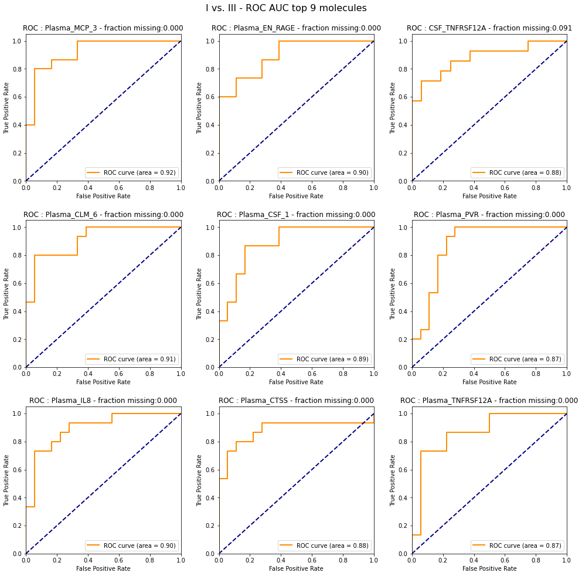

```python
sortedMolecules = sorted( roc_auc.items(), key = lambda x : x[1] , reverse=True)

fig,axes = plt.subplots(3,3 , figsize = (14,14))



for i, x in enumerate( sortedMolecules[:9] ):

    molec, roc_v = x

    ax = axes[ i%3 , i//3 ]

    print(molec, roc_v)
    plt.figure()
    lw = 2
    ax.plot(fpr[molec], tpr[molec], color='darkorange',
             lw=lw, label='ROC curve (area = %0.2f)' % roc_auc[molec])
    ax.plot([0, 1], [0, 1], color='navy', lw=lw, linestyle='--')
    ax.set_xlim([0.0, 1.0])
    ax.set_ylim([0.0, 1.05])
    ax.set_xlabel('False Positive Rate')
    ax.set_ylabel('True Positive Rate')
    ax.set_title('ROC : {} - fraction missing:{:.3f}'.format(molec, missing[molec]/data.shape[0]))
    ax.legend(loc="lower right")
fig.suptitle('I vs. III - ROC AUC top 9 molecules ', fontsize=16)
fig.tight_layout(pad=2.0)
fig.savefig( "images/I_III.ROC.pdf" )
```

```python
dfrocauc = pd.DataFrame({'molec' : [k[0] for k in sortedMolecules],
'roc_auc' : [ roc_auc[k[0]] for k in sortedMolecules ],
'fraction_missing' : [ missing[k[0]] for k in sortedMolecules ]})

dfrocauc.to_csv("marginalized_data/ROC_AUC_IvIII.csv")
```

### 2.2 II vs. III

```python
from sklearn.metrics import roc_auc_score
from sklearn.metrics import roc_curve, auc


M = df_metadata.index[ ( df_metadata.stageGroup == "II") | (df_metadata.stageGroup == "III") ]

data = df_molecular.loc[ M , : ]
grouping = df_metadata.loc[ M , 'stageGroup']
```

```python
data.shape
```

```
(22, 364)
```

```python
fpr = {}
tpr = {}
roc_auc = {}
missing = {}
for col in data.columns:

    nullMask = data[col].isnull()

    G = grouping[~nullMask]
    D = data.loc[~nullMask,col]



    fpr_loc, tpr_loc, _ = roc_curve(G, D , pos_label = 'III')
    roc_auc_loc = auc(fpr_loc, tpr_loc)


    if roc_auc_loc>0.5:
        fpr[col], tpr[col] , roc_auc[col] = fpr_loc, tpr_loc , roc_auc_loc
        missing[col] = nullMask.sum()
    else: #then it is better to use the opposite of the value to predict response
        lbl = '-('+col+')'
        fpr[lbl], tpr[lbl], _ = roc_curve(G, -D , pos_label = 'III')
        roc_auc[lbl] = auc(fpr[lbl], tpr[lbl])
        missing[lbl] = nullMask.sum()
```

```
CSF_IL18 0.9571428571428572
CSF_4E_BP1 0.9428571428571428
CSF_IL_18R1 0.9285714285714286
Plasma_TNFRSF12A 0.9142857142857143
CSF_CCL28 0.9
CSF_CD200R1 0.8999999999999999
Plasma_IL8 0.8952380952380952
CSF_CRTAM 0.8857142857142858
CSF_KYNU 0.8857142857142858
```

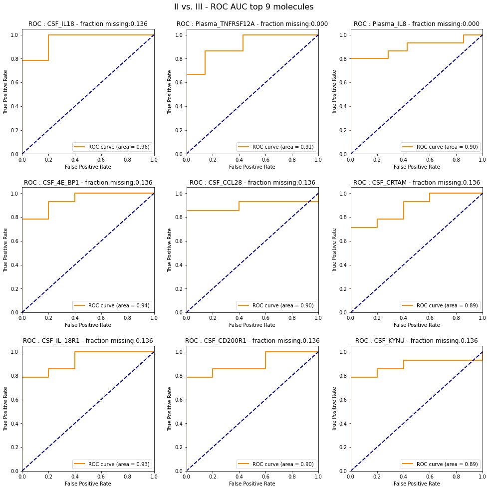

```python
sortedMolecules = sorted( roc_auc.items(), key = lambda x : x[1] , reverse=True)

fig,axes = plt.subplots(3,3 , figsize = (14,14))



for i, x in enumerate( sortedMolecules[:9] ):

    molec, roc_v = x

    ax = axes[ i%3 , i//3 ]

    print(molec, roc_v)
    plt.figure()
    lw = 2
    ax.plot(fpr[molec], tpr[molec], color='darkorange',
             lw=lw, label='ROC curve (area = %0.2f)' % roc_auc[molec])
    ax.plot([0, 1], [0, 1], color='navy', lw=lw, linestyle='--')
    ax.set_xlim([0.0, 1.0])
    ax.set_ylim([0.0, 1.05])
    ax.set_xlabel('False Positive Rate')
    ax.set_ylabel('True Positive Rate')
    ax.set_title('ROC : {} - fraction missing:{:.3f}'.format(molec, missing[molec]/data.shape[0]))
    ax.legend(loc="lower right")
fig.suptitle('II vs. III - ROC AUC top 9 molecules ', fontsize=16)
fig.tight_layout(pad=2.0)
fig.savefig( "images/II_III.ROC.pdf" )
```

```python
dfrocauc = pd.DataFrame({'molec' : [k[0] for k in sortedMolecules],
'roc_auc' : [ roc_auc[k[0]] for k in sortedMolecules ],
'fraction_missing' : [ missing[k[0]] for k in sortedMolecules ]})

dfrocauc.to_csv("marginalized_data/ROC_AUC_IIvIII.csv")
```

toc

### 2.3 I and II vs. III

This is the most clinically relevant experiment

```python
from sklearn.metrics import roc_auc_score
from sklearn.metrics import roc_curve, auc


M = df_metadata.index[ ( df_metadata.stageGroup == "I") | ( df_metadata.stageGroup == "II") | (df_metadata.stageGroup == "III") ]

data = df_molecular.loc[ M , : ]
grouping = df_metadata.loc[ M , 'stageGroup'].copy()
grouping[grouping=='I'] = "I/II"
grouping[grouping=='II'] = "I/II"
grouping.value_counts()
```

```
I/II    25
III     15
Name: stageGroup, dtype: int64
```

```python
data.shape
```

```
(40, 364)
```

```python
fpr = {}
tpr = {}
roc_auc = {}
missing = {}
for col in data.columns:

    nullMask = data[col].isnull()

    G = grouping[~nullMask]
    D = data.loc[~nullMask,col]



    fpr_loc, tpr_loc, _ = roc_curve(G, D , pos_label = 'III')
    roc_auc_loc = auc(fpr_loc, tpr_loc)


    if roc_auc_loc>0.5:
        fpr[col], tpr[col] , roc_auc[col] = fpr_loc, tpr_loc , roc_auc_loc
        missing[col] = nullMask.sum()
    else: #then it is better to use the opposite of the value to predict response
        lbl = '-('+col+')'
        fpr[lbl], tpr[lbl], _ = roc_curve(G, -D , pos_label = 'III')
        roc_auc[lbl] = auc(fpr[lbl], tpr[lbl])
        missing[lbl] = nullMask.sum()
```

```
Plasma_IL8 0.896
Plasma_TNFRSF12A 0.8826666666666667
CSF_EZR 0.8673469387755102
Plasma_EN_RAGE 0.8666666666666667
Plasma_MCP_3 0.864
CSF_TNFRSF12A 0.8639455782312925
CSF_4E_BP1 0.8639455782312925
-(Plasma_HAGH) 0.8613333333333333
CSF_MSR1 0.8571428571428571
```

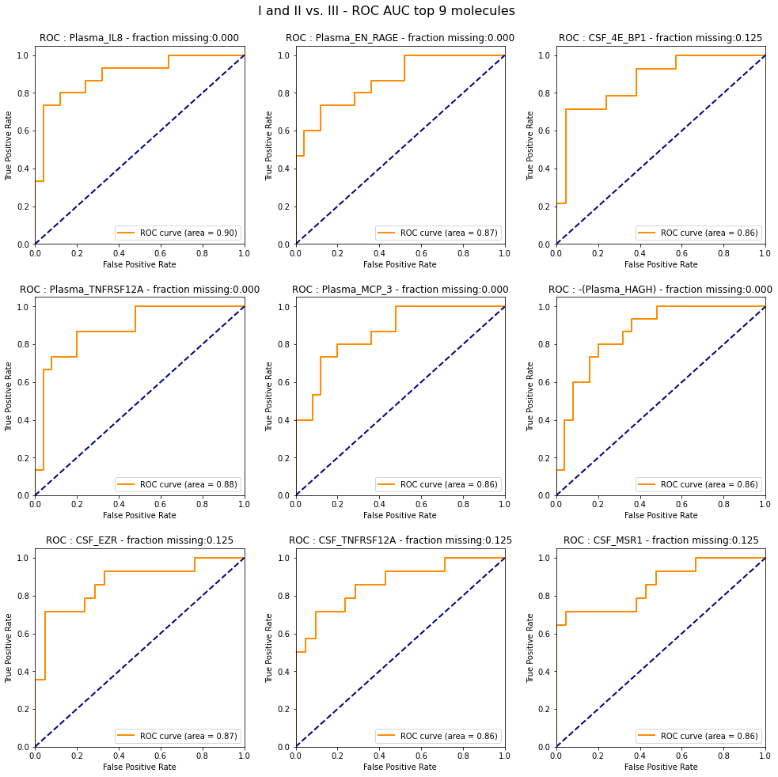

```python
sortedMolecules = sorted( roc_auc.items(), key = lambda x : x[1] , reverse=True)

fig,axes = plt.subplots(3,3 , figsize = (14,14))



for i, x in enumerate( sortedMolecules[:9] ):

    molec, roc_v = x

    ax = axes[ i%3 , i//3 ]

    print(molec, roc_v)
    plt.figure()
    lw = 2
    ax.plot(fpr[molec], tpr[molec], color='darkorange',
             lw=lw, label='ROC curve (area = %0.2f)' % roc_auc[molec])
    ax.plot([0, 1], [0, 1], color='navy', lw=lw, linestyle='--')
    ax.set_xlim([0.0, 1.0])
    ax.set_ylim([0.0, 1.05])
    ax.set_xlabel('False Positive Rate')
    ax.set_ylabel('True Positive Rate')
    ax.set_title('ROC : {} - fraction missing:{:.3f}'.format(molec, missing[molec]/data.shape[0]))
    ax.legend(loc="lower right")
fig.suptitle('I and II vs. III - ROC AUC top 9 molecules ', fontsize=16)
fig.tight_layout(pad=2.0)
fig.savefig( "images/I.II_III.ROC.pdf" )
```

```python
dfrocauc = pd.DataFrame({'molec' : [k[0] for k in sortedMolecules],
'roc_auc' : [ roc_auc[k[0]] for k in sortedMolecules ],
'fraction_missing' : [ missing[k[0]] for k in sortedMolecules ]})

dfrocauc.to_csv("marginalized_data/ROC_AUC_IandIIvIII.csv")
```

toc

## 3. random forest

```python
%%time
from sklearn.ensemble import RandomForestClassifier
from sklearn.model_selection import GridSearchCV
from sklearn.model_selection import LeaveOneOut
from sklearn.metrics import classification_report
from sklearn.metrics import accuracy_score, balanced_accuracy_score
from sklearn.impute import SimpleImputer
from sklearn.pipeline import Pipeline

N = data.shape[0]

##### Now we use RandomForestClassifier
grid_values = [{'RF__criterion': ['entropy','gini'],
               'RF__n_estimators':np.arange(1,500,100),
               'RF__max_depth':np.arange(2,int(np.ceil(N/10)),20),
               'RF__min_samples_split':np.arange(2,int(np.ceil(N/10)),20),
              'RF__min_samples_leaf':np.arange(1,int(np.ceil(N/10)),20),
              'RF__max_features':['sqrt','log2',None]}]


pipe = Pipeline([("imputer", SimpleImputer(strategy="mean")) ,
                ('RF',RandomForestClassifier(class_weight='balanced'))])
grid_tree_acc = GridSearchCV(pipe,
                             param_grid = grid_values,
                             cv = LeaveOneOut(),
                             scoring='balanced_accuracy',n_jobs=-1)


grid_tree_acc.fit(data, grouping)


print('Grid best parameter (max. balanced_accuracy): ', grid_tree_acc.best_params_)
print('Grid best score (balanced_accuracy): ', grid_tree_acc.best_score_)
```

[output not shown]

[output cut: 521 more lines]

[output not shown]

```
Grid best parameter (max. balanced_accuracy):  {'RF__criterion': 'entropy', 'RF__max_depth': 2, 'RF__max_features': 'log2', 'RF__min_samples_leaf': 1, 'RF__min_samples_split': 2, 'RF__n_estimators': 301}
Grid best score (balanced_accuracy):  0.8
CPU times: user 3.02 s, sys: 240 ms, total: 3.26 s
Wall time: 1min 56s
```

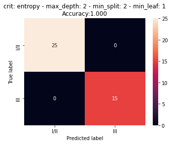

```python
from sklearn.metrics import confusion_matrix
y_pred=grid_tree_acc.predict(data)

confusion_mc_c = confusion_matrix(grouping, y_pred)
df_cm_c = pd.DataFrame(confusion_mc_c,
                     index = ["I/II","III"], columns = ["I/II","III"])

plt.figure(figsize=(5.5,4))
sns.heatmap(df_cm_c, annot=True)
plt.title(
    'crit: {} - max_depth: {} - min_split: {} - min_leaf: {}\nAccuracy:{:.3f}'.format(
        grid_tree_acc.best_params_['RF__criterion'],
        grid_tree_acc.best_params_['RF__max_depth'],
        grid_tree_acc.best_params_['RF__min_samples_split'],
        grid_tree_acc.best_params_['RF__min_samples_leaf'],
        balanced_accuracy_score(grouping, y_pred) ) )

plt.ylabel('True label')
plt.xlabel('Predicted label')
```

We are likely to be overfitting. Unfortunately the low sample size prevents us from a proper train/test split

Let's collect the importances to determine the best features

```python
w=grid_tree_acc.best_estimator_['RF'].feature_importances_#get the weights

featureW = pd.DataFrame( {'feature': data.columns,'weight':w} )

# sort them by absolute value
featureWsorted = featureW.sort_values(by=['weight'] ,
                                      ascending=False ,
                                      key=lambda col : col.abs())

# get the non-null ones
print('Features sorted per importance:')
featureWsorted.index = featureWsorted.feature
featureWsorted.iloc[ range(10) ]
```

```
Features sorted per importance:
```

| feature | feature | weight |
| --- | --- | --- |
| Plasma_IL8 | Plasma_IL8 | 0.025935 |
| CSF_CD200R1 | CSF_CD200R1 | 0.022219 |
| Plasma_PVR | Plasma_PVR | 0.020462 |
| Plasma_TNFRSF12A | Plasma_TNFRSF12A | 0.017284 |
| Plasma_IL_18R1 | Plasma_IL_18R1 | 0.017255 |
| Plasma_MSR1 | Plasma_MSR1 | 0.014222 |
| Plasma_MCP_3 | Plasma_MCP_3 | 0.014188 |
| CSF_MSR1 | CSF_MSR1 | 0.012361 |
| CSF_4E_BP1 | CSF_4E_BP1 | 0.011656 |
| Plasma_HAGH | Plasma_HAGH | 0.011535 |

```python
dfAUC = pd.read_csv("marginalized_data/ROC_AUC_IandIIvIII.csv", index_col=0)
dfAUC.index = dfAUC.molec.str.strip('-()')
dfAUC.head()
```

| molec | molec | roc_auc | fraction_missing |
| --- | --- | --- | --- |
| Plasma_IL8 | Plasma_IL8 | 0.896000 | 0 |
| Plasma_TNFRSF12A | Plasma_TNFRSF12A | 0.882667 | 0 |
| CSF_EZR | CSF_EZR | 0.867347 | 5 |
| Plasma_EN_RAGE | Plasma_EN_RAGE | 0.866667 | 0 |
| Plasma_MCP_3 | Plasma_MCP_3 | 0.864000 | 0 |

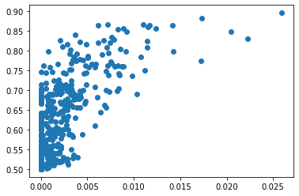

```python
dfAUC['importanceRF'] = featureWsorted.loc[dfAUC.index , 'weight']
plt.scatter(dfAUC['importanceRF'] , dfAUC['roc_auc'])
```

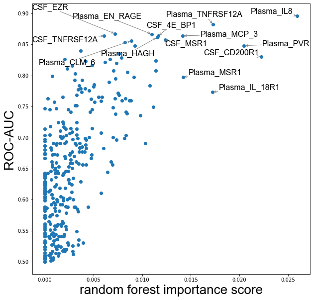

```python
bestAUC = dfAUC['roc_auc'].sort_values(ascending=False)[:10].index
bestRF = dfAUC['importanceRF'].sort_values(ascending=False)[:10].index
bestUnion = set(bestAUC).union(bestRF)
bestUnion



## label repelling from : https://python-graph-gallery.com/web-text-repel-with-matplotlib
from adjustText import adjust_text
fig,ax = plt.subplots(figsize=(10,10))

ax.scatter(dfAUC['importanceRF'] , dfAUC['roc_auc'] )
ax.set_xlabel("random forest importance score", fontsize = 26 , fontname = 'Arial')
ax.set_ylabel("ROC-AUC", fontsize = 26 , fontname = 'Arial')

TEXTS = []
for m in bestUnion:

    TEXTS.append( ax.text( x=dfAUC.loc[m,'importanceRF'],
                          y=dfAUC.loc[m,'roc_auc'],
                          fontname = 'Arial', fontsize=16,
                          s=m) )


adjust_text(TEXTS,
            expand_points=(1.2, 1.1), expand_text=(1.1,1.2),
            arrowprops=dict(arrowstyle="->", color="#7F7F7F", lw=1),
            ax=ax)
fig.savefig("images/classI+II_vs_III_prediction_ROCAUC_RFimportance.pdf")
fig.savefig("images/classI+II_vs_III_prediction_ROCAUC_RFimportance.png")
```

```python
dfAUC.loc[: , ["fraction_missing" , 'roc_auc' , 'importanceRF']].to_csv("supDocs/classI+II_vs_III_prediction_metrics.csv")
```

### conclusion/Methods:

We have trained a random forest to predict the patient class (I/II , or III) from all cytokine samples. We used leave-one-out cross-validation to optimize hyper-parameters and optimized a balanced accuracy metric. We then compare the ROC-AUC score of indicvidual molecules with their importance in the random forest.

Back to ToC

# 4. Random forest, Plasma only

let's perform the same analysis on plasma sample only.

```python
M = df_metadata.index[ ( df_metadata.stageGroup == "I") | ( df_metadata.stageGroup == "II") | (df_metadata.stageGroup == "III") ]
dataPlasma = df_molecular.loc[ M , [ c for c in df_molecular.columns if c.startswith("Plasma")] ]
```

```python
dataPlasma.shape
```

```
(40, 182)
```

```python
%%time
from sklearn.ensemble import RandomForestClassifier
from sklearn.model_selection import GridSearchCV
from sklearn.model_selection import LeaveOneOut
from sklearn.metrics import classification_report
from sklearn.metrics import accuracy_score, balanced_accuracy_score
from sklearn.impute import SimpleImputer
from sklearn.pipeline import Pipeline

N = data.shape[0]

##### Now we use RandomForestClassifier
grid_values = [{'RF__criterion': ['entropy','gini'],
               'RF__n_estimators':np.arange(1,200,10),
               'RF__max_depth':np.arange(2,int(np.ceil(N/10)),20),
               'RF__min_samples_split':np.arange(2,int(np.ceil(N/10)),20),
              'RF__min_samples_leaf':np.arange(1,int(np.ceil(N/10)),20),
              'RF__max_features':['sqrt','log2',None]}]


pipe = Pipeline([("imputer", SimpleImputer(strategy="mean")) ,
                ('RF',RandomForestClassifier(class_weight='balanced'))])
grid_tree_acc_plasma = GridSearchCV(pipe,
                             param_grid = grid_values,
                             cv = LeaveOneOut(),
                             scoring='balanced_accuracy',n_jobs=-1)


grid_tree_acc_plasma.fit(dataPlasma, grouping)


print('Grid best parameter (max. balanced_accuracy): ', grid_tree_acc_plasma.best_params_)
print('Grid best score (balanced_accuracy): ', grid_tree_acc_plasma.best_score_)
```

[output not shown]

[output cut: 2105 more lines]

[output not shown]

```
Grid best parameter (max. balanced_accuracy):  {'RF__criterion': 'entropy', 'RF__max_depth': 2, 'RF__max_features': 'sqrt', 'RF__min_samples_leaf': 1, 'RF__min_samples_split': 2, 'RF__n_estimators': 21}
Grid best score (balanced_accuracy):  0.825
CPU times: user 9.68 s, sys: 312 ms, total: 9.99 s
Wall time: 3min 11s
```

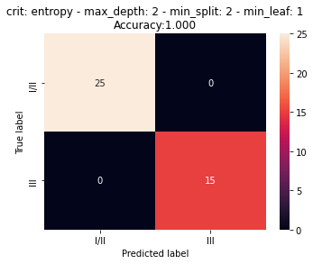

```python
from sklearn.metrics import confusion_matrix
y_pred=grid_tree_acc_plasma.predict(dataPlasma)

confusion_mc_c = confusion_matrix(grouping, y_pred)
df_cm_c = pd.DataFrame(confusion_mc_c,
                     index = ["I/II","III"], columns = ["I/II","III"])

plt.figure(figsize=(5.5,4))
sns.heatmap(df_cm_c, annot=True)
plt.title(
    'crit: {} - max_depth: {} - min_split: {} - min_leaf: {}\nAccuracy:{:.3f}'.format(
        grid_tree_acc_plasma.best_params_['RF__criterion'],
        grid_tree_acc_plasma.best_params_['RF__max_depth'],
        grid_tree_acc_plasma.best_params_['RF__min_samples_split'],
        grid_tree_acc_plasma.best_params_['RF__min_samples_leaf'],
        balanced_accuracy_score(grouping, y_pred) ) )

plt.ylabel('True label')
plt.xlabel('Predicted label')
```

Let's collect the importances to determine the best features

```python
w=grid_tree_acc_plasma.best_estimator_['RF'].feature_importances_#get the weights

featureW = pd.DataFrame( {'feature': dataPlasma.columns,'weight':w} )

# sort them by absolute value
featureWsorted = featureW.sort_values(by=['weight'] ,
                                      ascending=False ,
                                      key=lambda col : col.abs())

# get the non-null ones
print('Features sorted per importance:')
featureWsorted.index = featureWsorted.feature
featureWsorted.iloc[ range(10) ]
```

```
Features sorted per importance:
```

| feature | feature | weight |
| --- | --- | --- |
| Plasma_IL8 | Plasma_IL8 | 0.111957 |
| Plasma_MCP_3 | Plasma_MCP_3 | 0.074269 |
| Plasma_HAGH | Plasma_HAGH | 0.050968 |
| Plasma_HGF | Plasma_HGF | 0.044575 |
| Plasma_MSR1 | Plasma_MSR1 | 0.040128 |
| Plasma_LIF_R | Plasma_LIF_R | 0.038084 |
| Plasma_CX3CL1 | Plasma_CX3CL1 | 0.036099 |
| Plasma_DRAXIN | Plasma_DRAXIN | 0.033924 |
| Plasma_LAP_TGF_beta_1 | Plasma_LAP_TGF_beta_1 | 0.031486 |
| Plasma_IL6 | Plasma_IL6 | 0.030819 |

```python
dfAUC = pd.read_csv("marginalized_data/ROC_AUC_IandIIvIII.csv", index_col=0)
dfAUC.index = dfAUC.molec.str.strip('-()')
dfAUC.head()
```

| molec | molec | roc_auc | fraction_missing |
| --- | --- | --- | --- |
| Plasma_IL8 | Plasma_IL8 | 0.896000 | 0 |
| Plasma_TNFRSF12A | Plasma_TNFRSF12A | 0.882667 | 0 |
| CSF_EZR | CSF_EZR | 0.867347 | 5 |
| Plasma_EN_RAGE | Plasma_EN_RAGE | 0.866667 | 0 |
| Plasma_MCP_3 | Plasma_MCP_3 | 0.864000 | 0 |

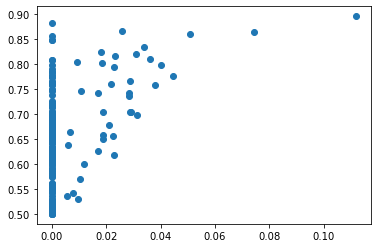

```python
dfAUC_plasma = dfAUC.loc[ featureWsorted.index  , [ 'fraction_missing' , 'roc_auc' ] ]

dfAUC_plasma['importanceRF'] = featureWsorted.loc[dfAUC_plasma.index , 'weight']

plt.scatter(dfAUC_plasma['importanceRF'] , dfAUC_plasma['roc_auc'])
```

```python
%load_ext autoreload

%autoreload 2
```

```python
import matplotlib.pyplot as plt
```

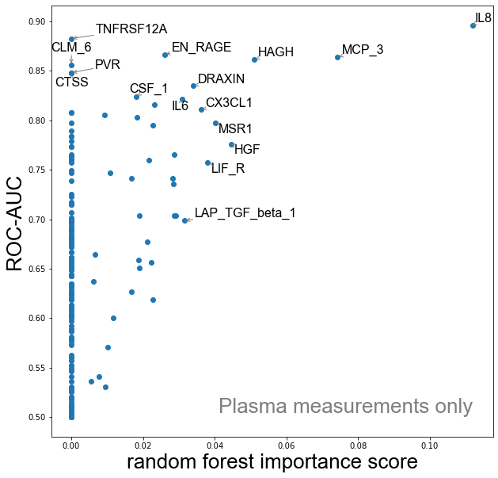

```python
## label repelling from : https://python-graph-gallery.com/web-text-repel-with-matplotlib
from adjustText import adjust_text

bestAUC = dfAUC_plasma['roc_auc'].sort_values(ascending=False)[:10].index
bestRF = dfAUC_plasma['importanceRF'].sort_values(ascending=False)[:10].index
bestUnion = set(bestAUC).union(bestRF)

fig,ax = plt.subplots(figsize=(10,10))

ax.scatter(dfAUC_plasma['importanceRF'] , dfAUC_plasma['roc_auc'] )
ax.set_xlabel("random forest importance score", fontsize = 26 , fontname = 'Arial')
ax.set_ylabel("ROC-AUC", fontsize = 26 , fontname = 'Arial')

TEXTS = []
for m in bestUnion:

    TEXTS.append( ax.text( x=dfAUC_plasma.loc[m,'importanceRF'],
                          y=dfAUC_plasma.loc[m,'roc_auc'],
                          fontname = 'Arial', fontsize=16,
                          s=m.partition('_')[2]) )

ax.text( x=dfAUC_plasma['importanceRF'].max(),
         y=dfAUC_plasma['roc_auc'].min(),
         fontname = 'Arial', color='#7F7F7F', fontsize=26,
         ha='right',
         va='bottom',
         s='Plasma measurements only')


adjust_text(TEXTS,
            expand_points=(1.2, 1.1), expand_text=(1.1,1.5),
            arrowprops=dict(arrowstyle="->", color="#7F7F7F", lw=1),
            ax=ax)
fig.savefig("images/classI+II_vs_III_prediction_ROCAUC_RFimportance_plasmaOnly.pdf")
fig.savefig("images/classI+II_vs_III_prediction_ROCAUC_RFimportance_plasmaOnly.png")
```

```python
dfAUC_plasma.to_csv("supDocs/classI+II_vs_III_prediction_metrics_plasmaOnly.csv")
```